# Catching Fraud in the Chat Box: Exploratory Analysis of a Simulated Banking77 Production Log

## 3.2 Review coverage

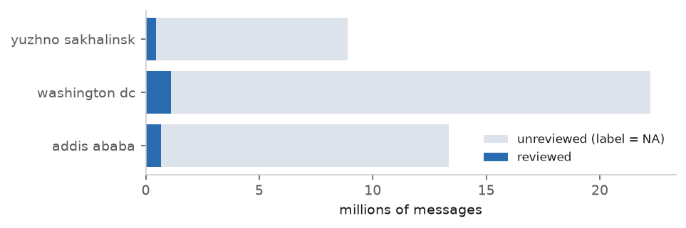

Figure 3: Reviewed vs unreviewed messages by branch.

2,221,185 of 44,464,114 rows have an intent label and the 5% share is the same in every branch. The remaining 95% is what the fraud ranking model has to work on. That is why the problem is a ranking problem before it is a classification problem: for the vast majority of rows there is nothing to compare a prediction against.

## 3.3 Message length

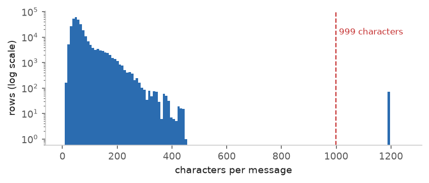

Figure 4: Message length. Note the logarithmic vertical axis.

Half of all messages are under 54 characters and the ordinary tail dies out around 450. The 8,758 rows past 999 characters are the planted token flooding attack and there is nothing in between.

That gap is a flaw in the simulation, not a result. A length threshold alone will perfectly separate the flooding here which is not how real flooding would behave. We will keep the length feature but will not tune against this margin.

## 3.4 Intent imbalance

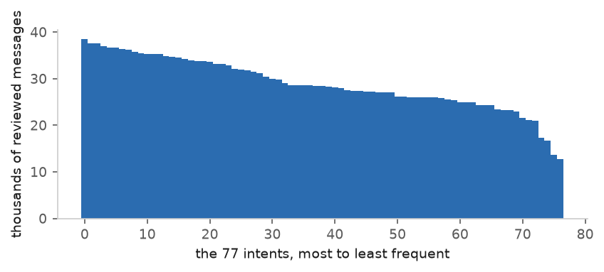

Figure 5: Reviewed messages per intent.

The most common intent (`card_payment_fee_charged`) has 38,560 reviewed messages and the least common (`contactless_not_working`) has 12,704. The 3.04 ratio is mild compared to most production label distributions but it is enough that overall accuracy will be higher than per-class recall. We will report macro-F1 alongside accuracy.

## 3.5 Vocabulary drift

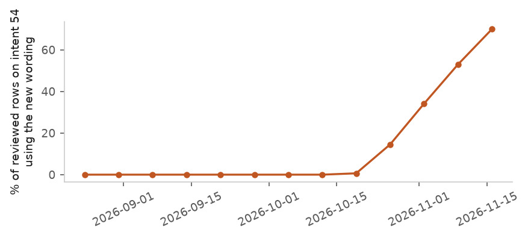

Figure 6: Share of reviewed intent 54 messages using the new wording by week.

This is the Zimbabwe gold case from the course vignette, planted on `supported_cards_and_currencies` (intent 54). Until late October no reviewed message on that intent uses the new wording; five weeks later 69% of them do.

The degradation is invisible in the aggregate. A single intent out of 77 shifting would barely move overall accuracy, so a monitor watching one global metric would not see it. Per-intent confidence tracking would.

# 4 Querying the lake

We ran one query (messages and reviewed messages per branch) three ways on the same S3 Parquet: once over all 90 days, once over a three week slice.

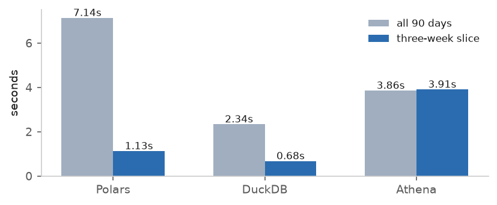

Figure 7: Wall-clock time for the same query on three engines.

Table 3: Wall-clock time, same query, same data.

| Engine | All 90 days | Three week slice | Speed-up |
| --- | --- | --- | --- |
| Polars | 7.14s | 1.13s | 6.3x |
| DuckDB | 2.34s | 0.68s | 3.4x |
| Athena | 3.86s | 3.91s | – |

Pruning helps both the local engines significantly and does nothing for Athena, as what Athena is spending here is start-up time rather than scanning.

Table 4: Bytes Athena actually read.

| Athena query | Data scanned |
| --- | --- |
| All 90 days | 5.9MB |
| Three week slice | 1.4MB |
| Files on disk | 1,990MB |

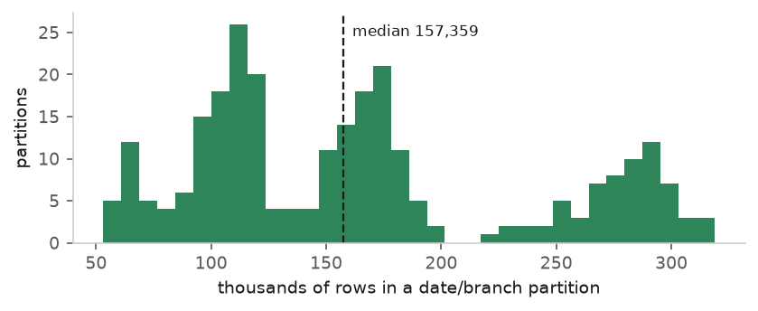

Figure 8: Rows per date/branch partition.

The 270 partitions run from 53,198 to 318,754 rows (a 6.0x spread). The three clusters in Figure 8 are the three branches. Within each the lower lobe is the weekend.

# 5 Caveats

**Only 492,380 distinct message texts across 44,464,114 rows (each message repeats about 90 times).** The perturbation applied during replay produces far fewer unique strings than the row count would suggest. If we split the rows at random we’d end up with near-identical messages in both train and test and the model would look a lot better than it is. We will split by message cohort or deduplicate prior to evaluation.

**The fraud labels are ours not Banking77’s.** Precision and recall on the planted rows is evidence of whether the pipeline catches the patterns we’ve planted. It is not evidence about real fraud.

**The partition sizes are uneven by construction.** Weekday-weekend rhythm and branch size drive the 6.0x spread so the imbalance is structural and will persist in any re-generation of the log.

# 6 References

Casanueva, I., Temčinas, T., Gerz, D., Henderson, M., & Vulić, I. (2020). Efficient intent detection with dual sentence encoders. *Proceedings of the 2nd Workshop on Natural Language Processing for Conversational AI*, 38–45. https://huggingface.co/datasets/PolyAI/banking77